# Home Work Assignment - 01

### Normality check of Residuals

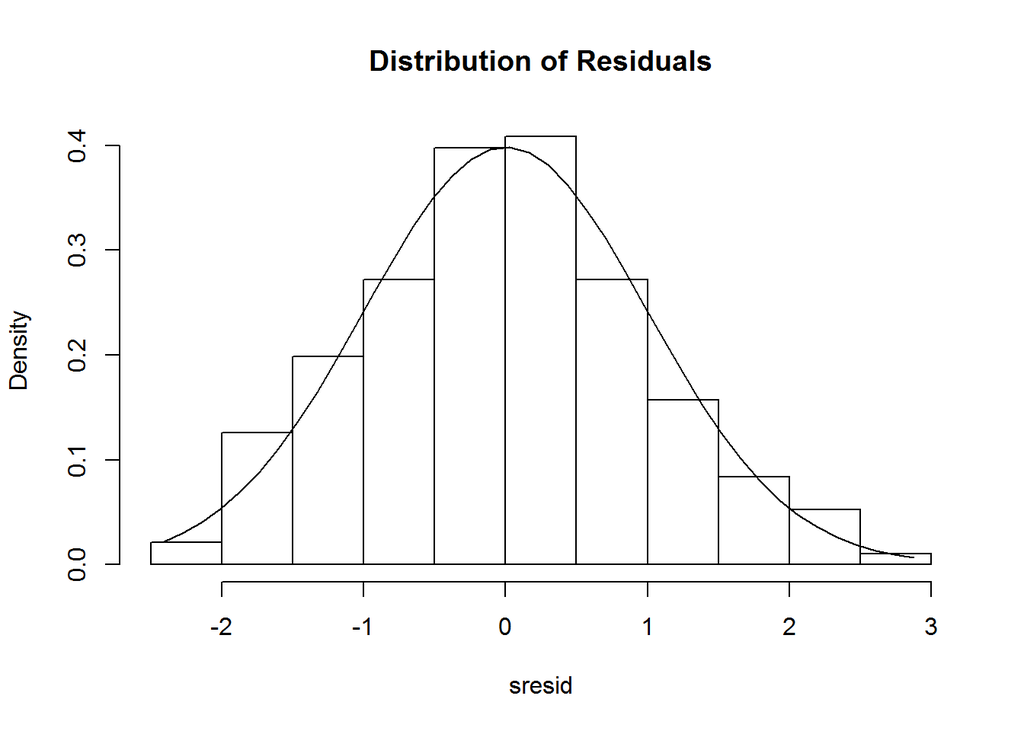

```r
#  First let plot residuals to see if they look like a normal distribution:

library(MASS)
sresid <- studres(mod1)
hist(sresid, freq=FALSE,
     main="Distribution of Residuals")
xfit<-seq(min(sresid),max(sresid),length=40)
yfit<-dnorm(xfit)
lines(xfit, yfit)
```

#### The residuals are normally distributed, this indicates That the mean of the difference between our predictions

#### and the actual values is close to 0 which is good for our analysis.

#### Also, it’s unlikely that no relationship exists between TEAM_FIELDING_E and TARGET_WINS.

### homoscedasticity check or non-constant error variance test

```r
# Evaluate homoscedasticity
ncvTest(mod1)
```

```
## Non-constant Variance Score Test
## Variance formula: ~ fitted.values
## Chisquare = 0.03994848    Df = 1     p = 0.8415813
```

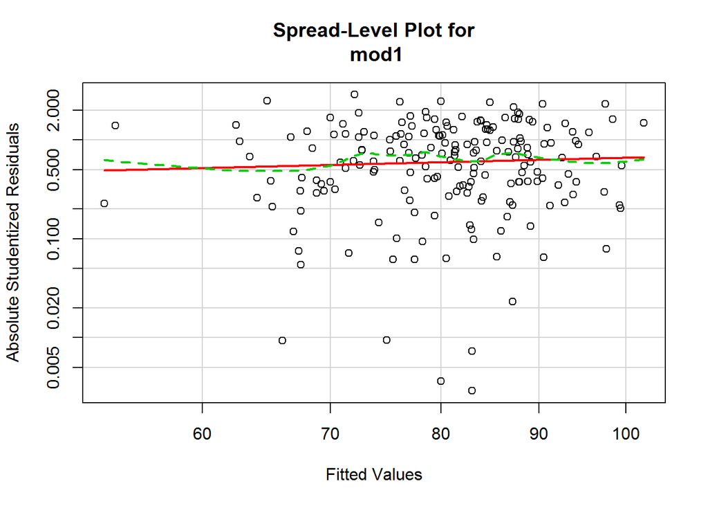

```
##
## Suggested power transformation:  0.5267026
```

```r
# plot studentized residuals vs. fitted values
spreadLevelPlot(mod1)
```

#### The test confirms the non-constant error variance test. It also has a p-value higher than a significance level of 0.05.

#### Therefore we can accept the null hypothesis that the variance of the residuals is constant and infer that heteroscedasticity is not present.

### Collinearity Check

```r
# Evaluate Collinearity
vif(mod1) # variance inflation factors
```

```
##   TEAM_BATTING_H  TEAM_BATTING_2B  TEAM_BATTING_3B  TEAM_BATTING_HR
##     1.171824e+05     1.685623e+00     1.302198e+00     3.074804e+05
##  TEAM_BATTING_BB TEAM_BATTING_HBP  TEAM_BATTING_SO  TEAM_BASERUN_SB
##     1.962853e+05     1.096334e+00     1.941752e+05     1.950069e+00
##  TEAM_BASERUN_CS  TEAM_FIELDING_E TEAM_FIELDING_DP TEAM_PITCHING_BB
##     1.914415e+00     1.256819e+00     1.097611e+00     1.964039e+05
##  TEAM_PITCHING_H TEAM_PITCHING_HR TEAM_PITCHING_SO
##     1.160417e+05     3.069624e+05     1.946316e+05
```

```r
Collinearity<- sqrt(vif(mod1)) > 3 # 3 problem?
data.frame(Collinearity)
```

```
##                  Collinearity
## TEAM_BATTING_H           TRUE
## TEAM_BATTING_2B         FALSE
## TEAM_BATTING_3B         FALSE
## TEAM_BATTING_HR          TRUE
## TEAM_BATTING_BB          TRUE
## TEAM_BATTING_HBP        FALSE
## TEAM_BATTING_SO          TRUE
## TEAM_BASERUN_SB         FALSE
## TEAM_BASERUN_CS         FALSE
## TEAM_FIELDING_E         FALSE
## TEAM_FIELDING_DP        FALSE
## TEAM_PITCHING_BB         TRUE
## TEAM_PITCHING_H          TRUE
## TEAM_PITCHING_HR         TRUE
## TEAM_PITCHING_SO         TRUE
```

# Test for Autocorrelated Errors

durbinWatsonTest(mod1)

```r
durbinWatsonTest(mod1)
```

```
##  lag Autocorrelation D-W Statistic p-value
##    1       0.2128921      1.567453   0.002
##  Alternative hypothesis: rho != 0
```

### goodness of fit of your model

### using R-squared and adjusted R-squared, our model is about 55% predicts the TARGET_WINS